# R Notebook

```r
library(tidyverse)
library(CodeClanData)
```

[output not shown]

[output cut: 26 more lines]

4 MVP 4.1 Part 1 1. Take the data in the dataset qb_revenue_breakdown and make a stacked bar chart showing the sources of revenue across the two years in the dataset.

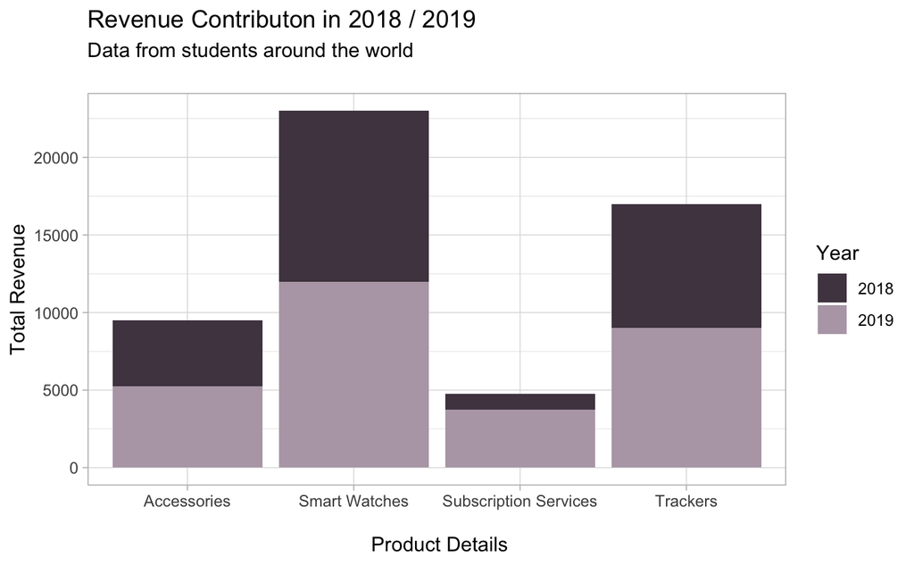

```r
ggplot(qb_revenue_breakdown) +
  geom_bar(aes(x = Product, y = Revenue, fill = Year), stat = "identity") +
  labs(
    x = "\n Product Details",
    y = "Total Revenue",
    title = "Revenue Contributon in 2018 / 2019",
    subtitle = "Data from students around the world\n",
    fill = "Year"
       ) +
  theme_light() +
  scale_fill_manual(values = c("#50434F", "#B6A7B5"))
```

```r
NA
```

2. Make a line chart showing monthly sales of the “flagship product” - the KwikBit Unit1 - over the last year. This data is inside qb_monthly_sales, but you will need to use subset.

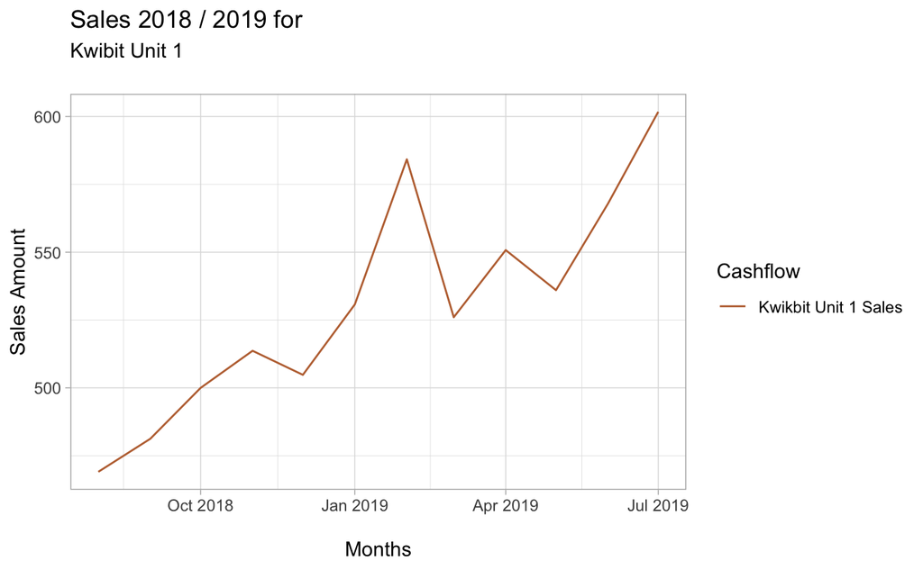

```r
Kwikbit_Unit_1_Sales <- subset(qb_monthly_sales, Cashflow == "Kwikbit Unit 1 Sales", Date < 2019-01-01)

ggplot(Kwikbit_Unit_1_Sales) +
  geom_line(aes( x = Date , y = Amount, colour = Cashflow)) +
  labs(
    x = "\nMonths",
    y = "Sales Amount",
    title = "Sales 2018 / 2019 for",
    subtitle = "Kwibit Unit 1\n"
  )+
  theme_light() +
  scale_colour_manual(values = c("#BD7040"))
```

```r
NA
NA
```

Make a line chart showing monthly revenue and costs over the last year. This data is also in qb_monthly_sales.

```r
total_revenue <- subset(qb_monthly_sales, Cashflow = "Total Revenue", "Cost")
```

[output not shown]

[output not shown]

```
Error in subset.data.frame(qb_monthly_sales, Cashflow = "Total Revenue",  :
  'subset' must be logical
```

Show annual sales of personal fitness trackers over the last 5 years broken down by company as a ribbon plot (use geom_area). This data is in qb_competitors.

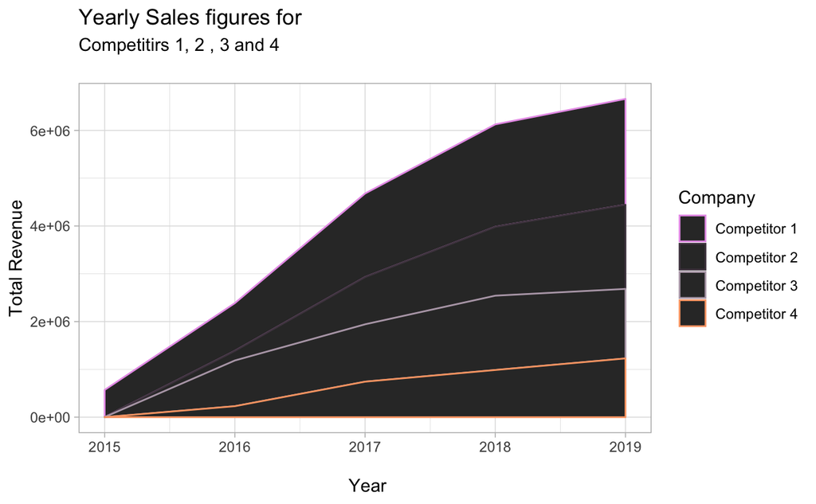

```r
ggplot(qb_competitors) +
  geom_area(aes(x= Year, y=Revenue, colour=Company)) +
  labs(
    x = "\n Year",
    y = "Total Revenue",
    title = "Yearly Sales figures for ",
    subtitle = "Competitirs 1, 2 , 3 and 4\n"
       ) +
  theme_light() +
  scale_colour_manual(values = c("#E89FE9", "#50434F", "#B6A7B5", "#F9A472", "#BD7040"))
```

```r
NA
NA
```

```r
qb_competitors
```

[output not shown]

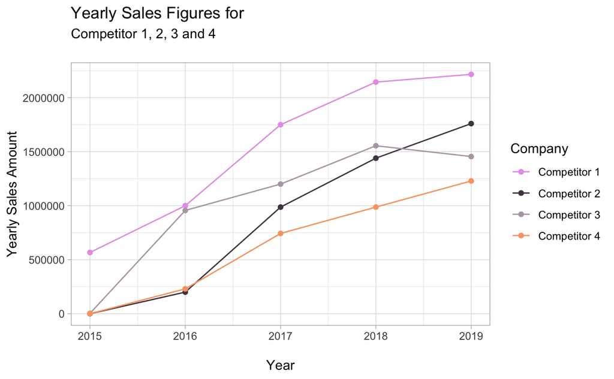

```r
ggplot(qb_competitors) +
  geom_line(
    aes(x = Year, y = Revenue, group = Company, colour = Company)) +
  geom_point(
    aes(x = Year, y = Revenue, colour = Company)) +
   labs(
    x = "\nYear",
    y = "Yearly Sales Amount",
    title = "Yearly Sales Figures for",
    subtitle = "Competitor 1, 2, 3 and 4\n"
  ) +
  theme_light() +
  scale_colour_manual(values = c("#E89FE9", "#50434F", "#B6A7B5", "#F9A472", "#BD7040"))
```

Now the company wants to compare the number of steps that their device counts vs. their competitors. Make a line graph of the number of steps throughout time, and use faceting to compare between individuals and people. Data is in qb_device_data.

```r
names(qb_device_data)
```

```
[1] "device" "id"     "hours"  "mins"   "counts"
```

```r
ggplot(qb_device_data) +
  geom_line(
    aes(x = Time, y = count, group = id, colour = device))
```

[output not shown]